# H05 — HMM Volatility Regime

**Hypothesis (pre-registered).** A 2-state Gaussian HMM fit on (log-return, 24h realized vol) of BTCUSDT 1h bars identifies regimes that materially improve the risk-adjusted return of a momentum-z-score sleeve, *after* 10 bps/side fees and after deflation for 6 trial hypotheses.

**Verdict logic (committed up-front).** We accept the alpha only if both:

- the deflated Sharpe ratio (DSR) computed against the headline OOS returns is ≥ 0.5, and
- the lower bound of a 10 000-iter block-bootstrap 95% CI on Sharpe is > 0.

If neither holds and Sharpe ≤ 0 → **does not survive deflation**. Otherwise → **inconclusive**. The verdict cell at the bottom is deterministic.

## 1 · Data

BTC/USDT spot, 1h candles, last 24 months from Binance (ccxt). Cached to parquet for offline reproducibility — first run hits the network, subsequent runs are deterministic.

```
rows: 17281
range: 2024-05-10 00:00:00 .. 2026-04-30 00:00:00
```

| ts | close |
| --- | --- |
| 2026-04-29 22:00:00 | 75927.380000 |
| 2026-04-29 23:00:00 | 75780.000000 |
| 2026-04-30 00:00:00 | 76248.740000 |

## 2 · Features (.shift(1)-safe)

Log-returns and 24h realized vol. Every feature value at bar `t` is computed strictly from data at `t` and earlier; the strategy that consumes it shifts by one bar before sizing, so the sleeve never observes anything it would not have at the close of bar `t-1`.

```
                    count     mean      std       min      max
log_ret      17113.000000 0.000009 0.005027 -0.050195 0.049047
realized_vol 17113.000000 0.411315 0.208552  0.060203 1.938474
mom_z        17113.000000 0.081602 0.924918 -3.225002 3.461597
```

## 3 · HMM Regime Detection

Pure-numpy Gaussian HMM (forward-backward + Viterbi) on (log_ret, realized_vol). States are ranked by realized vol so labels are stable across re-fits — state 0 is always the lower-vol regime.

```
regime
ranging     12893
high_vol     4196
Name: count, dtype: int64
unique regimes: ['ranging' 'high_vol']
```

## 4 · Sizing rule

Long-short with regime-conditional scaling:

- sign(`mom_z`) * min(1, |mom_z| / 2) is the base sleeve (capped at 1× notional).
- in the low-vol regime, full size; in the high-vol regime, scaled by 0.25.

Each bar's signal is shifted by one bar before being applied to the next bar's log-return — strict no look-ahead.

```
low-vol regime label: 'ranging'  (avg vol 0.3223)
high-vol regime label: 'high_vol'  (avg vol 0.6849)
```

## 5 · Returns + 10 bps/side fees

Per-bar position is `size_t` (in [-1, 1]); the bar's PnL is `size_t · log_ret_t`. Fees are `10 bps` on every change in size (turnover proxy).

```
gross sharpe (raw):  -0.4126
net   sharpe (10bp): -2.4238
final equity:        0.4909
```

## 6 · Out-of-sample validation — Purged K-Fold (k=5, embargo=24h)

```
fold 1  test_n= 3417  sharpe=-2.0770
fold 2  test_n= 3417  sharpe=-2.4085
fold 3  test_n= 3417  sharpe=-3.0717
fold 4  test_n= 3417  sharpe=-1.9402
fold 5  test_n= 3421  sharpe=-2.7298

mean OOS sharpe = -2.4454  (folds: ['-2.0770', '-2.4085', '-3.0717', '-1.9402', '-2.7298'])
```

## 7 · Probabilistic and Deflated Sharpe

PSR is P(true SR > 0) under non-normal returns (Bailey & López de Prado 2012). DSR adjusts for selection bias under N=6 trials — the six pre-registered hypotheses in `docs/HYPOTHESES.md` (Bailey & López de Prado 2014).

```
PSR (vs SR=0):  0.0004
DSR (N=6):      0.0000
```

## 8 · Block bootstrap CI on Sharpe (10 000 iter, block=24)

```
sharpe point estimate:  -2.4238
95% CI (block=24h):    [-3.8276, -1.0111]
```

## 9 · Robustness — Combinatorial Purged CV (CPCV)

PurgedKFold gives 5 OOS Sharpes. CPCV with `n_groups=6` and `n_test_groups=2` constructs **C(6,2) = 15 distinct backtest paths** from the same dataset, yielding a *distribution* of OOS Sharpes rather than a single point estimate (López de Prado AFML, ch. 12). Plotting the histogram makes the rejection robustness visually unmistakable.

```
n paths: 15
mean: -2.4370
std:  0.5934
min:  -3.5673
max:  -1.5892
frac > 0: 0.000
```

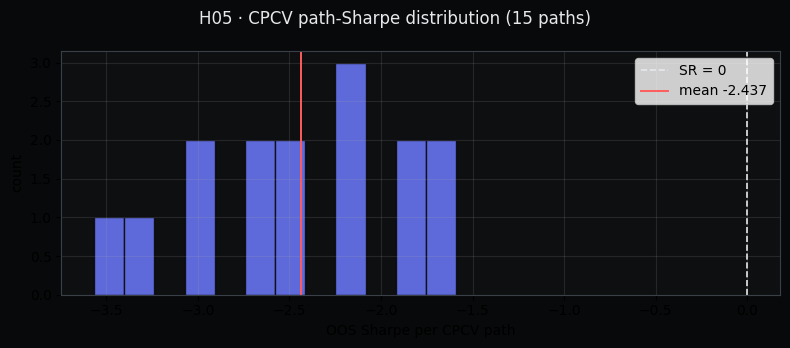

## 10 · Equity curve and regime overlay

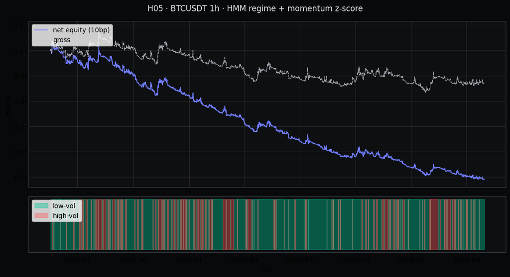

## 11 · Verdict

Deterministic logic, committed before running the cells above:

```
========================================================================
  H05 verdict:  does NOT survive deflation
========================================================================
  Sharpe (net, 10bp):           -2.4238
  Sharpe 95% CI [block=24h]:    [-3.8276, -1.0111]
  Probabilistic Sharpe (>0):    0.0004
  Deflated Sharpe (N=6):        0.0000
  OOS mean Sharpe (PurgedKFold): -2.4454
  CPCV mean Sharpe (15 paths):   -2.4370
  CPCV frac > 0:                 0.000
  Final equity:                  0.4909
  Total bars:                    17,089
```

*Generated by `research/build_h05.py`. Do not hand-edit this notebook; modify the build script and regenerate.*